# Executive Summary

Final Project  
Data Science 2 with R (STAT 301-2)

Author

Jeremy Ferguson

Published

March 13, 2024

**Github Repo Link**

https://github.com/stat301-2-2024-winter/final-project-2-jeremyferg.git

# Abstract

This project aims to create a predictive model that can estimate the yearly salaries of professional basketball players from the National Basketball Association (NBA). This model uses season statistics from players as its predictors. Other NBA-related factors, such as the location of the player’s team and how long the player has been in the NBA, are also used for the analysis.

In this regression analysis, I am most concerned about the accuracy of my models’ estimation; I want to be able to predict NBA salaries as closely as possible, as this is the main value a player or agent is concerned with. I also suspect there to be outliers in my data. Therefore RMSE is the assessment metric for this project.

# Methods

The main methodology highlight of this project is the usage of various predictive recipes to help conclude the best performance metric. These recipes are used in conjugation with several predictive models focused on flexibility and interpretability.

The first recipe focuses on general player statistics, such as points, assists, and rebounds. This recipe is simplistic and minimizes the complexity of the modeling process. The second recipe will place a heavy focus on interaction terms; Complexity may come from how predictors interact with each other. The third recipe decreases the number of interaction terms used and adds nonlinearity complexity, capturing nonlinear trends found in several predictors. The last recipe places focus on predictors that are not completely in the player’s control, such as their team’s market size, their position, and whether or not their team makes the playoffs.

# Model Analysis

Figure 1 visualizes the performance metric of each of our models using the three targeted recipes (the nonlinear recipe was ultimately dropped). When we compare RMSE values, we look for small means and standard errors. The figure helps us see that many of the models from the interaction recipe produced smaller RMSE values in comparison to other results. Looking at the performance metrics of the interaction recipe, we can see that neural networks, MARS, and random forests all have the same minimizing mean with slightly different standard errors. The random forest model is ultimately chosen for its interpretability, simplicity, and time cost relative to the other two models.

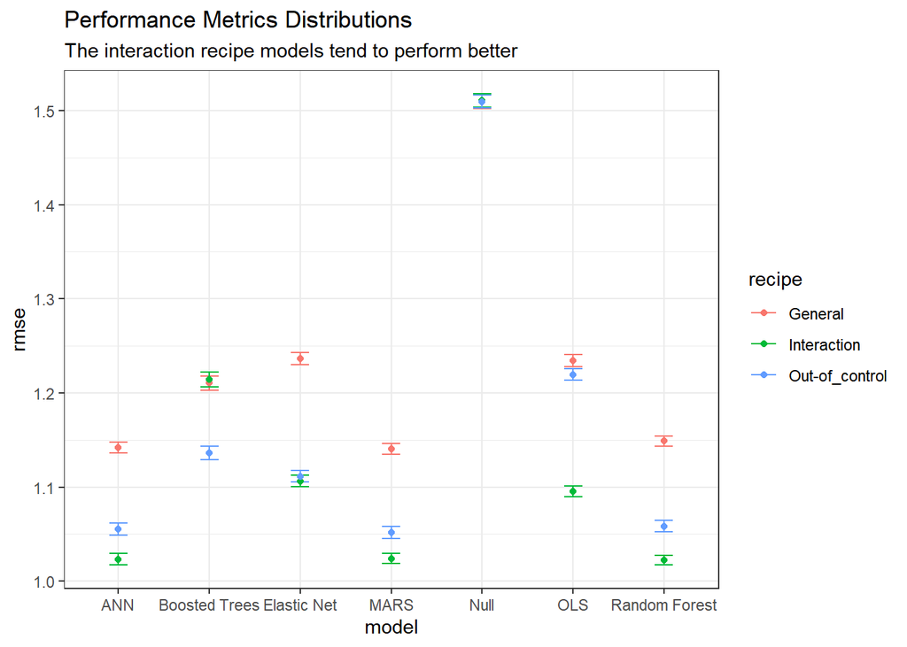

Figure 1

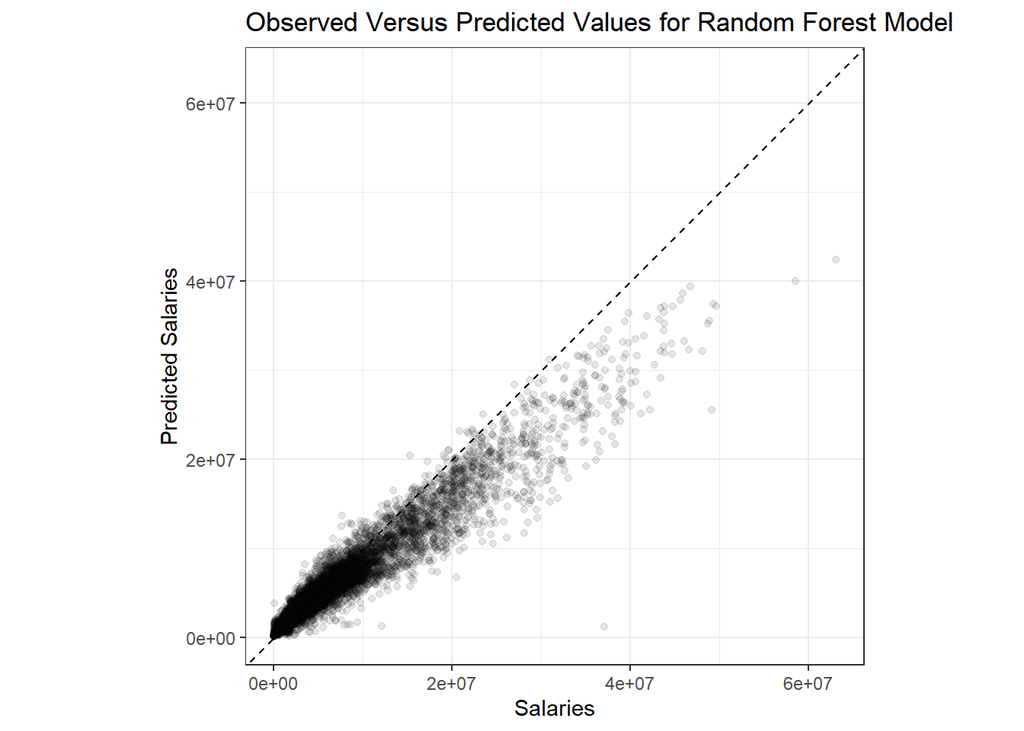

Figure 2

# Future Research

This project successfully created a predictive model that can estimate NBA seasonal salaries based on season statistics of a player. I found it interesting that even though there are many intricate basketball-related statistics, fairly simple metrics and interactions between them can explain a significant portion of expected salaries. While I believe I did a solid job with my results, there is still room to re-tune a lot of my models. Retuning the models could lead to lower RMSE values, alleviating some of my dissatisfaction with the value of RMSE in my final fit model.